# PrevisioneDelleInsolvenze

Ilaria_Pasini,Francesco_Gabellini

25/3/2020

##File con i passaggi per analisi su Insolvenze

##Manipolazioni sul dataset

Apro librerie necessarie e importo i seed per ottenere stessi risultati su piu macchine

```r
library(tidyverse)
library(readxl)
library(ggmap)
library(maps)
library(pROC)
library(ROCR)
library(data.table)
library(car)
library(Rcmdr)
library(psych)
library(FactoMineR)
library(caret)
library(biotools)
library(MVN)
library(MASS)
library(NeuralNetTools)
library(nnet)
setwd("C:/Users/gabel/Desktop/ProgettoInsolvenze")
set.seed(42)
```

Importo dati da excel

```r
df <- read_excel("C:/Users/gabel/Desktop/ProgettoInsolvenze/Export_Aida.xlsx")
df$FlagFallimento <-  as.factor(df$FlagFallimento )
df <- as.data.frame(df)
```

##Statistiche Descrittive Su DataSet

ROA:

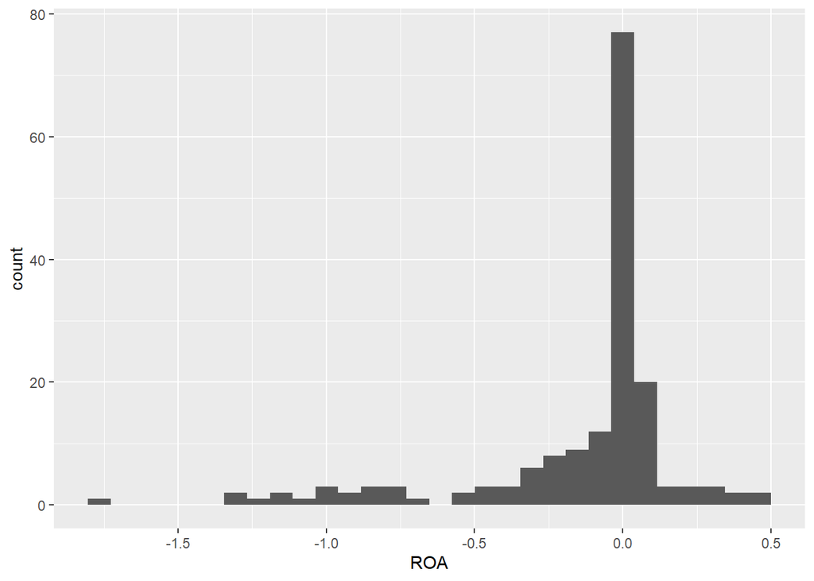

```r
ggplot(data=df,
       mapping=aes(x=ROA))+
geom_histogram()
```

```r
summary(df$ROA)
```

```
##       Min.    1st Qu.     Median       Mean    3rd Qu.       Max.
## -1.7293792 -0.1498805  0.0003301 -0.1343203  0.0206147  0.4972558
```

Rotazione:

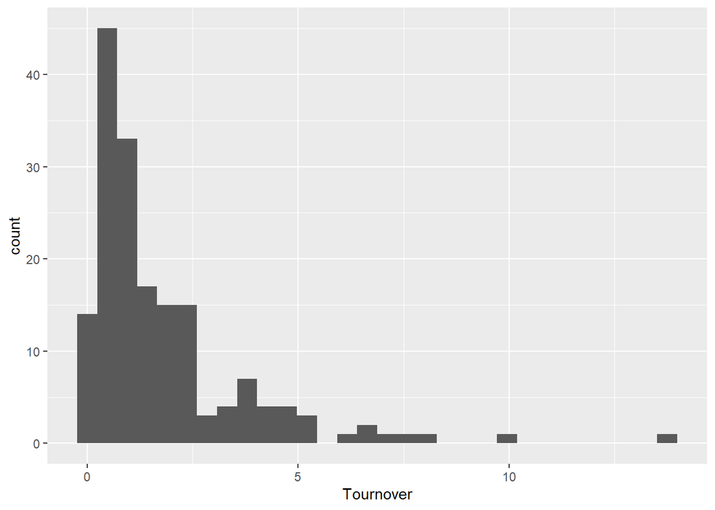

```r
ggplot(data=df,
       mapping=aes(x=Tournover))+
geom_histogram()
```

```r
summary(df$Tournover)
```

```
##      Min.   1st Qu.    Median      Mean   3rd Qu.      Max.
##  0.004835  0.610247  1.111688  1.788942  2.183495 13.747485
```

EBITDA:

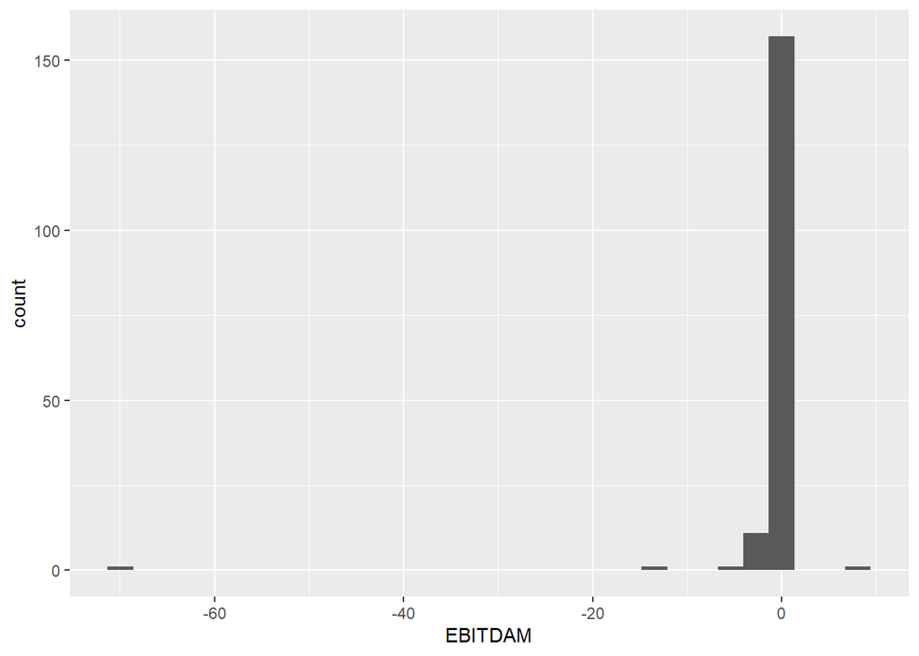

```r
ggplot(data=df,
       mapping=aes(x=EBITDAM))+
geom_histogram()
```

```r
summary(df$EBITDAM)
```

```
##      Min.   1st Qu.    Median      Mean   3rd Qu.      Max.
## -69.58905  -0.19270   0.02268  -0.66175   0.06491   8.44951
```

INDIPENDEZA:

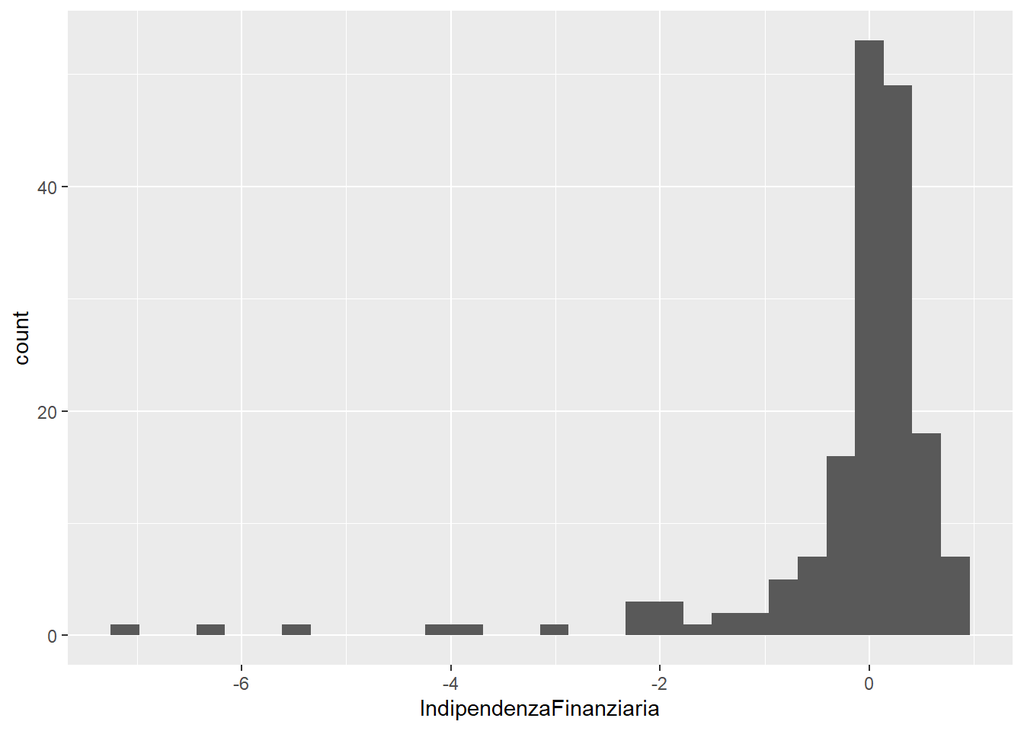

```r
ggplot(data=df,
       mapping=aes(x=IndipendenzaFinanziaria))+
geom_histogram()
```

```r
summary(df$IndipendenzaFinanziaria)
```

```
##     Min.  1st Qu.   Median     Mean  3rd Qu.     Max.
## -7.13469 -0.17523  0.08107 -0.18869  0.25994  0.80295
```

LIQUIDITA:

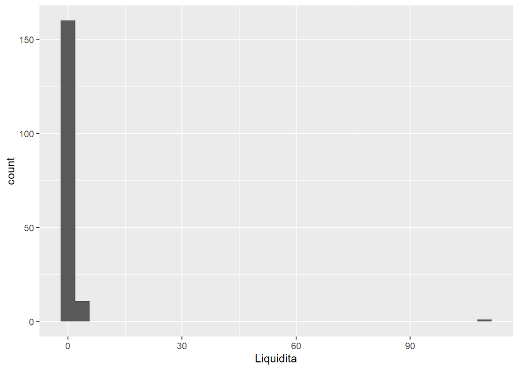

```r
ggplot(data=df,
       mapping=aes(x=Liquidita))+
geom_histogram()
```

```r
summary(df$Liquidita)
```

```
##      Min.   1st Qu.    Median      Mean   3rd Qu.      Max.
##   0.01621   0.17753   0.39712   1.30270   0.87472 109.59722
```

Creo Mappa Delle Aziende

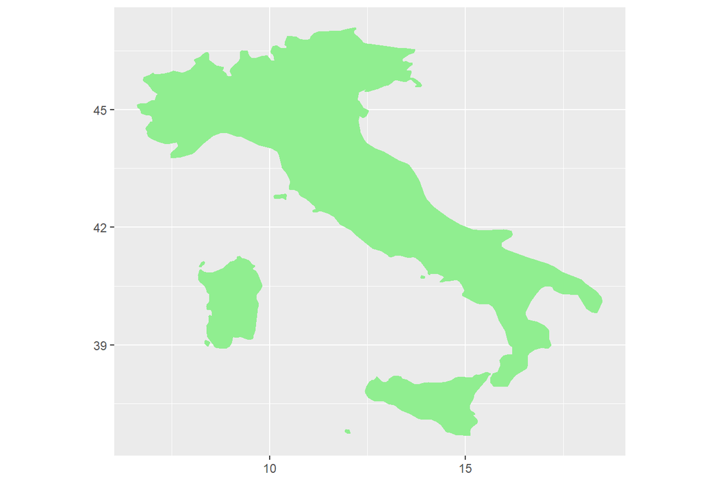

```r
library(maps)
library(ggplot2)
world_map <- map_data("world")



Italy <- subset(world_map, world_map$region=="Italy")
p <- ggplot() + coord_fixed() +
  xlab("") + ylab("")
ItalyMap <- p +
                      geom_polygon(data=Italy, aes(x=long, y=lat, group=group),
                               colour="light green", fill="light green")
ItalyMap
```

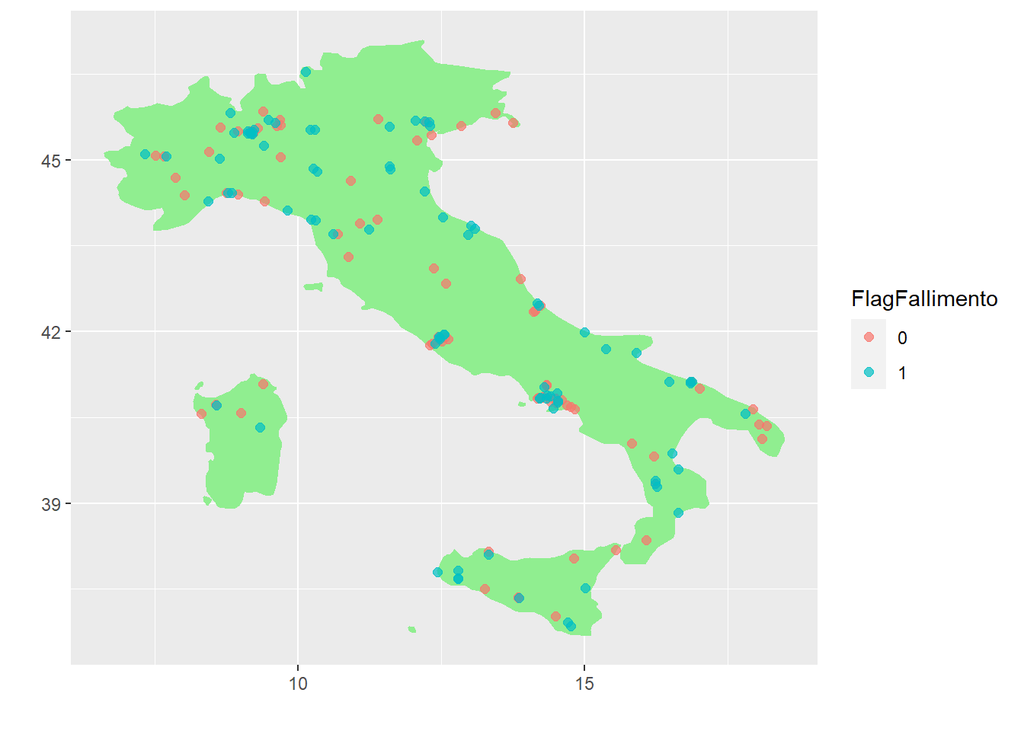

```r
map_data <-
  ItalyMap +
  geom_point(data=df,
             aes(x=as.numeric(lon), y=as.numeric(lat), color=FlagFallimento)
             , size=2, alpha=I(0.7))

map_data
```

Restringo df a Soli Indici

```r
dfR <- df %>%
  dplyr::select(ROA,EBITDAM,Tournover,  IndipendenzaFinanziaria,    Liquidita   ,FlagFallimento,MacroQuartili)
```

Verifico ipotesi per Modello LDA:

Omogeneita varianza:

```r
boxM(dfR[1:5],dfR$FlagFallimento)
```

```
##
##  Box's M-test for Homogeneity of Covariance Matrices
##
## data:  dfR[1:5]
## Chi-Sq (approx.) = 992.11, df = 15, p-value < 2.2e-16
```

Non c’è omogeneità nei due gruppi quindi non possiamo applicare LDA.

Distrubuzione multivariata su sub-set di dati:

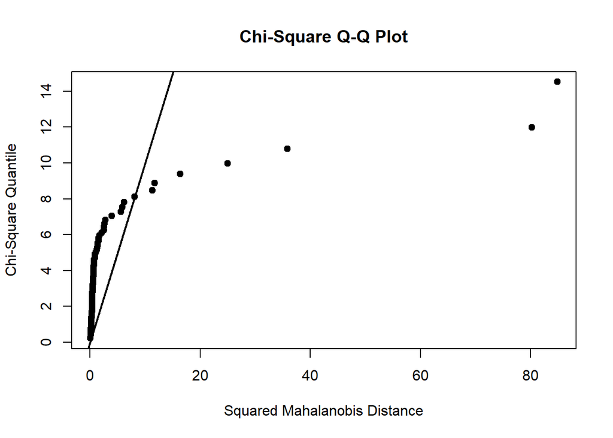

```
## $multivariateNormality
##              Test        Statistic p value Result
## 1 Mardia Skewness 2427.76695160269       0     NO
## 2 Mardia Kurtosis 111.028579669114       0     NO
## 3             MVN             <NA>    <NA>     NO
##
## $univariateNormality
##           Test                Variable Statistic   p value Normality
## 1 Shapiro-Wilk         EBITDAM            0.1975  <0.001      NO
## 2 Shapiro-Wilk        Tournover           0.6600  <0.001      NO
## 3 Shapiro-Wilk IndipendenzaFinanziaria    0.6587  <0.001      NO
## 4 Shapiro-Wilk        Liquidita           0.1036  <0.001      NO
##
## $Descriptives
##                          n       Mean   Std.Dev      Median           Min
## EBITDAM                 86 -1.3407529  7.681310 -0.14334050 -69.589052384
## Tournover               86  1.5922888  2.162562  0.73041775   0.004834839
## IndipendenzaFinanziaria 86 -0.5895528  1.421791 -0.04145575  -7.134689290
## Liquidita               86  1.6932919 11.782544  0.25776038   0.016208601
##                                Max       25th       75th      Skew
## EBITDAM                   8.449507 -0.5651096 0.02731831 -8.165811
## Tournover                13.747485  0.4177401 2.10424305  2.953059
## IndipendenzaFinanziaria   0.776636 -0.6632765 0.07389431 -2.682490
## Liquidita               109.597222  0.1348110 0.49711389  8.929325
##                          Kurtosis
## EBITDAM                 69.548606
## Tournover               11.136564
## IndipendenzaFinanziaria  7.710023
## Liquidita               78.789097
```

```r
fallite <- dfR %>%
        filter (FlagFallimento==1) %>%
        dplyr::select( ROA  ,EBITDAM,   Tournover,  IndipendenzaFinanziaria,    Liquidita)
sane <- dfR %>%
        filter (FlagFallimento==0) %>%
        dplyr::select( ROA  ,EBITDAM,   Tournover,  IndipendenzaFinanziaria,    Liquidita)

mvn(fallite[2:5],mvnTest="mardia",cov=TRUE,multivariatePlot="qq")
```

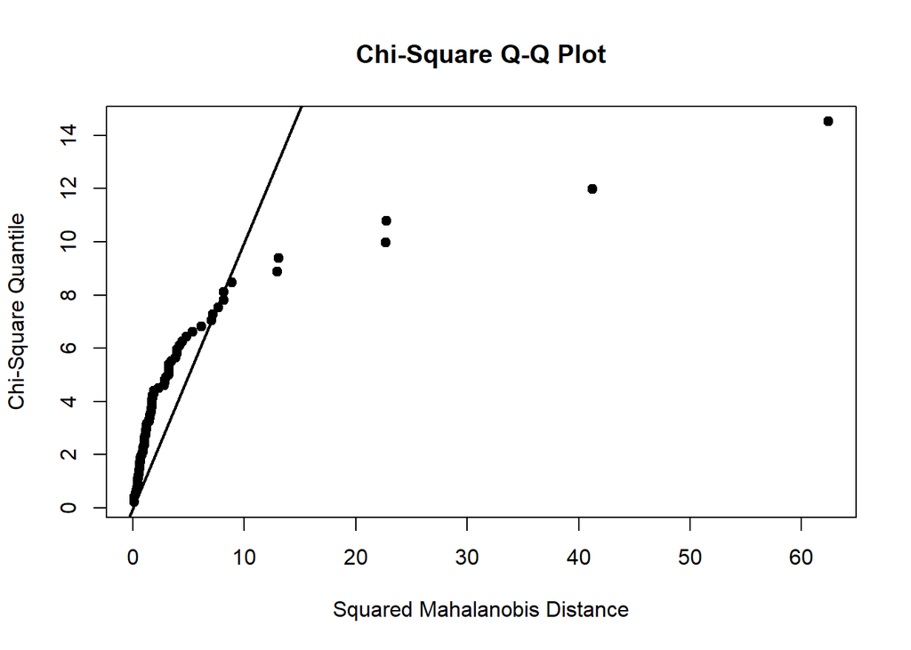

```
## $multivariateNormality
##              Test        Statistic               p value Result
## 1 Mardia Skewness 676.032883899608 2.59230568032944e-130     NO
## 2 Mardia Kurtosis 43.6425340241436                     0     NO
## 3             MVN             <NA>                  <NA>     NO
##
## $univariateNormality
##           Test                Variable Statistic   p value Normality
## 1 Shapiro-Wilk         EBITDAM            0.4290  <0.001      NO
## 2 Shapiro-Wilk        Tournover           0.8010  <0.001      NO
## 3 Shapiro-Wilk IndipendenzaFinanziaria    0.8664  <0.001      NO
## 4 Shapiro-Wilk        Liquidita           0.7500  <0.001      NO
##
## $Descriptives
##                          n      Mean   Std.Dev     Median         Min
## EBITDAM                 86 0.0172436 0.2547371 0.04025995 -1.92435782
## Tournover               86 1.9855960 1.7421364 1.35163950  0.01123701
## IndipendenzaFinanziaria 86 0.2121811 0.3059668 0.21115939 -1.46048406
## Liquidita               86 0.9121171 1.0020053 0.56391902  0.01689967
##                                Max       25th       75th      Skew
## EBITDAM                  0.9682738 0.02000205 0.07335021 -4.660328
## Tournover               10.1596821 0.78586388 2.30509191  1.936684
## IndipendenzaFinanziaria  0.8029521 0.08549165 0.38196322 -1.759263
## Liquidita                4.4764940 0.23935769 1.16462449  1.963690
##                          Kurtosis
## EBITDAM                 38.732444
## Tournover                4.763269
## IndipendenzaFinanziaria  8.766131
## Liquidita                3.538929
```

```r
mvn(sane[2:5],mvnTest="mardia",cov=TRUE,multivariatePlot="qq")
```

Non c’è nemmeno normalità distributiva

## Analisi Delle Componenti Principali

PCA su factoMineR

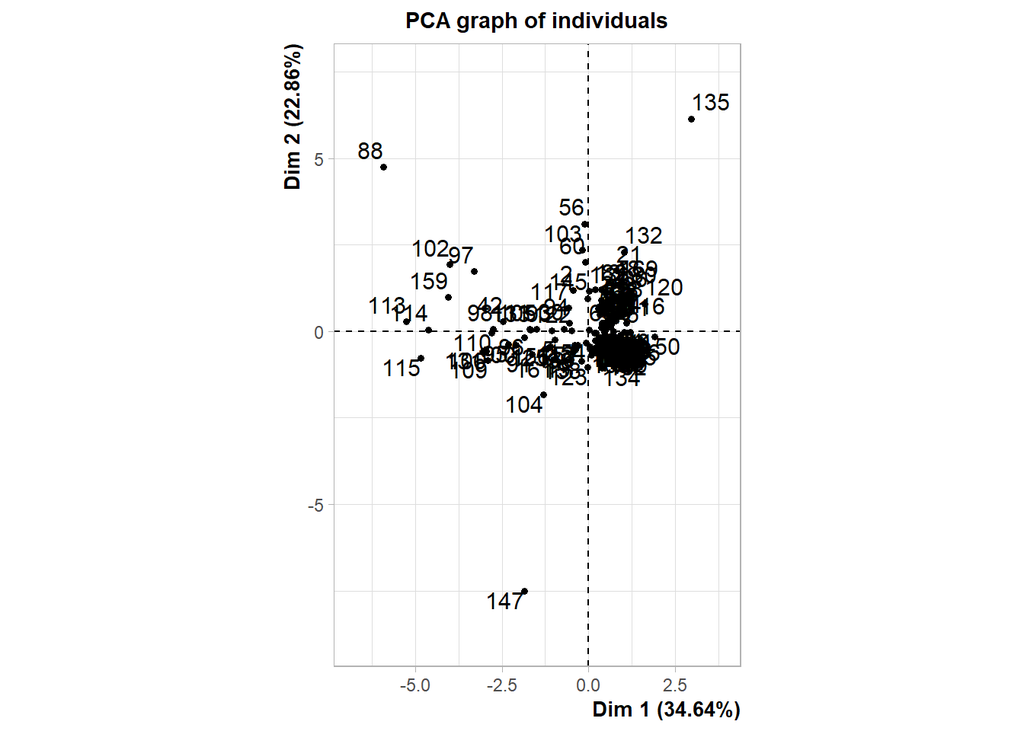

```r
dati.PCA<-dfR[, c("ROA","EBITDAM","Tournover",  "IndipendenzaFinanziaria",  "Liquidita")]
res<-PCA(dati.PCA , scale.unit=TRUE, ncp=5, graph = FALSE)
plot.PCA(res, axes=c(1, 2), choix="ind", habillage="none", col.ind="black",
  col.ind.sup="blue", col.quali="magenta", label=c("ind", "ind.sup", "quali"),
  new.plot=TRUE)
```

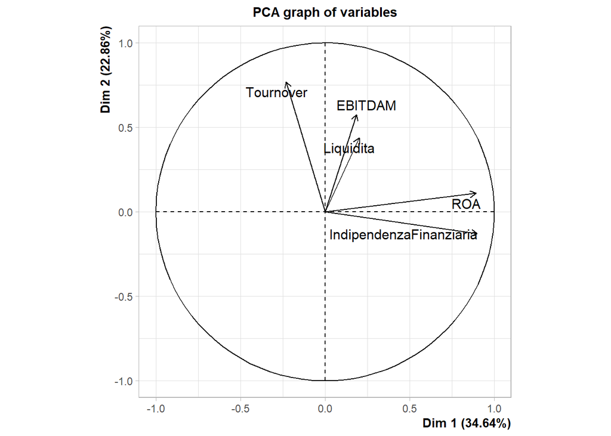

```r
plot.PCA(res, axes=c(1, 2), choix="var", new.plot=TRUE, col.var="black",
  col.quanti.sup="blue", label=c("var", "quanti.sup"), lim.cos2.var=0)
```

```r
summary(res, nb.dec = 3, nbelements=10, nbind = 10, ncp = 3, file="")
```

```
##
## Call:
## PCA(X = dati.PCA, scale.unit = TRUE, ncp = 5, graph = FALSE)
##
##
## Eigenvalues
##                        Dim.1   Dim.2   Dim.3   Dim.4   Dim.5
## Variance               1.732   1.143   0.999   0.812   0.314
## % of var.             34.642  22.864  19.982  16.238   6.274
## Cumulative % of var.  34.642  57.506  77.488  93.726 100.000
##
## Individuals (the 10 first)
##                             Dist    Dim.1    ctr   cos2    Dim.2    ctr
## 1                       |  1.610 |  0.021  0.000  0.000 |  1.153  0.677
## 2                       |  1.676 | -0.438  0.064  0.068 |  1.175  0.702
## 3                       |  0.962 |  0.821  0.226  0.728 | -0.403  0.083
## 4                       |  1.270 |  1.215  0.495  0.915 | -0.034  0.001
## 5                       |  1.306 | -0.974  0.318  0.557 | -0.252  0.032
## 6                       |  0.871 |  0.624  0.131  0.513 | -0.434  0.096
## 7                       |  0.605 |  0.241  0.019  0.159 | -0.239  0.029
## 8                       |  0.658 |  0.564  0.107  0.737 | -0.232  0.027
## 9                       |  0.569 |  0.455  0.069  0.640 | -0.147  0.011
## 10                      |  0.980 |  0.670  0.151  0.468 | -0.524  0.139
##                           cos2    Dim.3    ctr   cos2
## 1                        0.513 | -0.144  0.012  0.008 |
## 2                        0.491 | -0.098  0.006  0.003 |
## 3                        0.176 | -0.174  0.018  0.033 |
## 4                        0.001 | -0.159  0.015  0.016 |
## 5                        0.037 | -0.106  0.007  0.007 |
## 6                        0.249 | -0.206  0.025  0.056 |
## 7                        0.156 | -0.097  0.005  0.026 |
## 8                        0.125 | -0.189  0.021  0.083 |
## 9                        0.067 | -0.206  0.025  0.131 |
## 10                       0.286 | -0.111  0.007  0.013 |
##
## Variables
##                            Dim.1    ctr   cos2    Dim.2    ctr   cos2
## ROA                     |  0.892 45.890  0.795 |  0.109  1.044  0.012 |
## EBITDAM                 |  0.187  2.013  0.035 |  0.576 29.011  0.332 |
## Tournover               | -0.230  3.056  0.053 |  0.769 51.671  0.591 |
## IndipendenzaFinanziaria |  0.899 46.710  0.809 | -0.129  1.460  0.017 |
## Liquidita               |  0.201  2.332  0.040 |  0.438 16.814  0.192 |
##                          Dim.3    ctr   cos2
## ROA                     -0.023  0.052  0.001 |
## EBITDAM                 -0.634 40.281  0.402 |
## Tournover                0.037  0.139  0.001 |
## IndipendenzaFinanziaria -0.008  0.007  0.000 |
## Liquidita                0.771 59.521  0.595 |
```

```r
remove(dati.PCA)
```

Ruoto le componenti principali per dargli un significato al meglio tramite altro pacchetto

```r
data_rot<-subset(dfR, select = c(ROA,EBITDAM,Tournover,IndipendenzaFinanziaria,Liquidita))
ro<-principal(data_rot,nfactors=2,rotate = "varimax", scores = T)
ro
```

```
## Principal Components Analysis
## Call: principal(r = data_rot, nfactors = 2, rotate = "varimax", scores = T)
## Standardized loadings (pattern matrix) based upon correlation matrix
##                           RC1   RC2   h2   u2 com
## ROA                      0.88  0.20 0.81 0.19 1.1
## EBITDAM                  0.13  0.59 0.37 0.63 1.1
## Tournover               -0.30  0.74 0.64 0.36 1.3
## IndipendenzaFinanziaria  0.91 -0.04 0.83 0.17 1.0
## Liquidita                0.16  0.46 0.23 0.77 1.2
##
##                        RC1  RC2
## SS loadings           1.73 1.15
## Proportion Var        0.35 0.23
## Cumulative Var        0.35 0.58
## Proportion Explained  0.60 0.40
## Cumulative Proportion 0.60 1.00
##
## Mean item complexity =  1.2
## Test of the hypothesis that 2 components are sufficient.
##
## The root mean square of the residuals (RMSR) is  0.17
##  with the empirical chi square  98.2  with prob <  3.8e-23
##
## Fit based upon off diagonal values = 0.46
```

Creo nuovo dataframe con le prime 2 componenti principali

```r
dfPCA <- ro$scores
dfPCA <- as.data.frame(dfPCA)
```

Metto componenti principali nel dataset con le altre variabili

```r
dati_finali<-cbind.data.frame(dfR,dfPCA)
```

Ora faccio mappa fattoriale degli individui

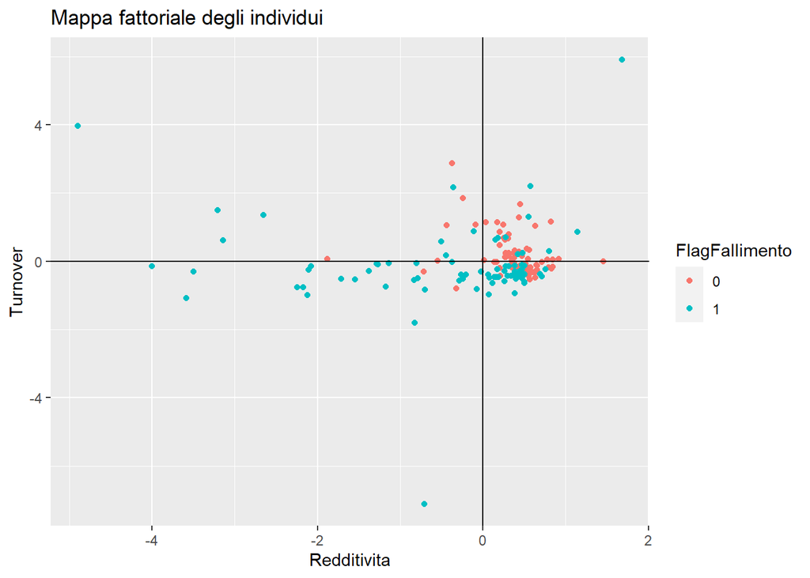

```r
ggplot(data=dati_finali)+
      geom_point(mapping = aes(x=RC1,y=RC2,color=FlagFallimento))+
      geom_hline(yintercept = 0)+
      geom_vline(xintercept = 0)+
      xlab("Redditivita")+
      ylab("Turnover")+
      labs(title = "Mappa fattoriale degli individui")
```

##Modelli Previsioni Insolvenze

Creo Train e Test Stratificati

```r
dati_finali %>%
  dplyr::select(FlagFallimento, MacroQuartili) %>%
  group_by(FlagFallimento, MacroQuartili) %>%
  group_indices() -> indeces

trainDataIndex <- createDataPartition(as.factor(indeces), p=0.7)[[1]]
trainData <- dati_finali[trainDataIndex, ]
testData <- dati_finali[-trainDataIndex, ]
```

Verifico Stratificazione

```r
count(trainData, MacroQuartili)
```

```
## # A tibble: 20 x 2
##    MacroQuartili     n
##    <chr>         <int>
##  1 Q1CE             62
##  2 Q1IS              2
##  3 Q1NE              1
##  4 Q1NO              4
##  5 Q1SU              2
##  6 Q2CE              6
##  7 Q2IS              3
##  8 Q2NE              2
##  9 Q2NO              5
## 10 Q2SU              3
## 11 Q3CE              2
## 12 Q3IS              2
## 13 Q3NE              3
## 14 Q3NO              4
## 15 Q3SU              9
## 16 Q4CE              3
## 17 Q4IS              3
## 18 Q4NE              3
## 19 Q4NO              5
## 20 Q4SU              8
```

```r
count(testData, MacroQuartili)
```

```
## # A tibble: 10 x 2
##    MacroQuartili     n
##    <chr>         <int>
##  1 Q1CE             25
##  2 Q1NO              1
##  3 Q2CE              2
##  4 Q2IS              1
##  5 Q2NO              2
##  6 Q3NO              1
##  7 Q3SU              3
##  8 Q4NE              1
##  9 Q4NO              1
## 10 Q4SU              3
```

Stratificazione Avvenuto con successo passo a modellistica

Regressione Logistica

```r
Logistica <- glm(FlagFallimento ~ ROA   +EBITDAM+Tournover+IndipendenzaFinanziaria+ Liquidita,
                family=binomial(link='logit'),data=trainData)
```

Summary

```r
summary(Logistica)
```

```
##
## Call:
## glm(formula = FlagFallimento ~ ROA + EBITDAM + Tournover + IndipendenzaFinanziaria +
##     Liquidita, family = binomial(link = "logit"), data = trainData)
##
## Deviance Residuals:
##     Min       1Q   Median       3Q      Max
## -2.5795  -0.9445  -0.6146   1.0737   2.2489
##
## Coefficients:
##                         Estimate Std. Error z value Pr(>|z|)
## (Intercept)              0.05103    0.31204   0.164  0.87010
## ROA                      0.12033    1.05417   0.114  0.90912
## EBITDAM                  0.03652    0.16840   0.217  0.82829
## Tournover               -0.14617    0.13067  -1.119  0.26329
## IndipendenzaFinanziaria -2.32780    0.82971  -2.806  0.00502 **
## Liquidita                0.04352    0.05254   0.828  0.40752
## ---
## Signif. codes:  0 '***' 0.001 '**' 0.01 '*' 0.05 '.' 0.1 ' ' 1
##
## (Dispersion parameter for binomial family taken to be 1)
##
##     Null deviance: 182.23  on 131  degrees of freedom
## Residual deviance: 146.52  on 126  degrees of freedom
## AIC: 158.52
##
## Number of Fisher Scoring iterations: 6
```

Coefficienti

```r
exp(coef(Logistica))
```

```
##             (Intercept)                     ROA                 EBITDAM
##              1.05235135              1.12787149              1.03719949
##               Tournover IndipendenzaFinanziaria               Liquidita
##              0.86400854              0.09750983              1.04447843
```

Predict Classi e Probabilità

```r
Output <- predict(Logistica, newdata=testData, type="response")
Output <- as.data.frame(Output)

Output$Class[Output$Output < 0.5] <- 0
Output$Class[Output$Output >= 0.5] <- 1
```

Confusion Matrix e Metriche

```r
confusionMatrix(as.factor(Output$Class), testData$FlagFallimento)
```

```
## Confusion Matrix and Statistics
##
##           Reference
## Prediction  0  1
##          0 15 13
##          1  0 12
##
##                Accuracy : 0.675
##                  95% CI : (0.5087, 0.8143)
##     No Information Rate : 0.625
##     P-Value [Acc > NIR] : 0.3161405
##
##                   Kappa : 0.4091
##
##  Mcnemar's Test P-Value : 0.0008741
##
##             Sensitivity : 1.0000
##             Specificity : 0.4800
##          Pos Pred Value : 0.5357
##          Neg Pred Value : 1.0000
##              Prevalence : 0.3750
##          Detection Rate : 0.3750
##    Detection Prevalence : 0.7000
##       Balanced Accuracy : 0.7400
##
##        'Positive' Class : 0
##
```

Curva Roc

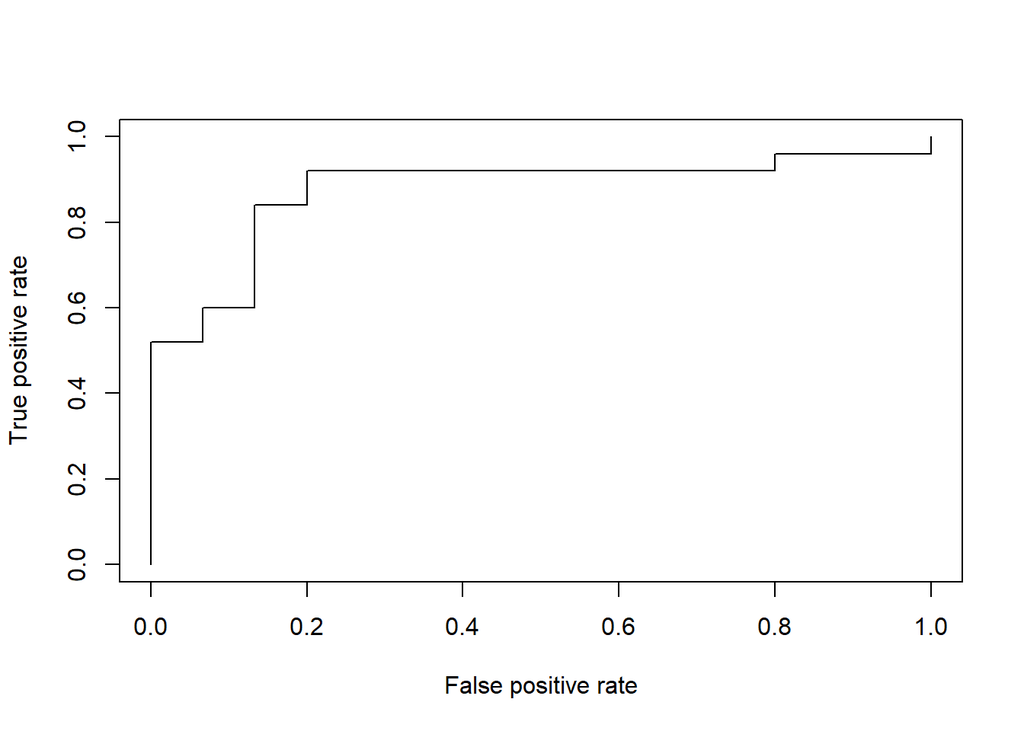

```r
prob <- predict(Logistica, newdata=testData, type="response")
pred <- prediction(prob, testData$FlagFallimento)
perf <- performance(pred, measure = "tpr", x.measure = "fpr")
plot(perf)
```

AUC

```r
auc <- performance(pred, measure = "auc")
auc <- auc@y.values[[1]]
auc
```

```
## [1] 0.8746667
```

Regressione Logistica con Cross-Validation

```r
ctrl <- trainControl(method = "repeatedcv", number = 100, savePredictions = TRUE)

mod_fit <- caret::train ( FlagFallimento ~  ROA + EBITDAM + Tournover + IndipendenzaFinanziaria +   Liquidita,
                        data=trainData, method="glm", family="binomial",
                        trControl = ctrl, tuneLength = 5)
pred = predict(mod_fit, newdata=testData)
confusionMatrix(data=pred, testData$FlagFallimento)
```

```
## Confusion Matrix and Statistics
##
##           Reference
## Prediction  0  1
##          0 15 13
##          1  0 12
##
##                Accuracy : 0.675
##                  95% CI : (0.5087, 0.8143)
##     No Information Rate : 0.625
##     P-Value [Acc > NIR] : 0.3161405
##
##                   Kappa : 0.4091
##
##  Mcnemar's Test P-Value : 0.0008741
##
##             Sensitivity : 1.0000
##             Specificity : 0.4800
##          Pos Pred Value : 0.5357
##          Neg Pred Value : 1.0000
##              Prevalence : 0.3750
##          Detection Rate : 0.3750
##    Detection Prevalence : 0.7000
##       Balanced Accuracy : 0.7400
##
##        'Positive' Class : 0
##
```

Regressione Logistica con PCA Regressione Logistica

```r
Logistica_pca <- glm(FlagFallimento ~ RC1+RC2,
                family=binomial(link='logit'),data=trainData)
```

```r
exp(coef(Logistica_pca))
```

```
## (Intercept)         RC1         RC2
##   0.9763578   0.3332219   0.8471002
```

Summary

```r
summary(Logistica_pca)
```

```
##
## Call:
## glm(formula = FlagFallimento ~ RC1 + RC2, family = binomial(link = "logit"),
##     data = trainData)
##
## Deviance Residuals:
##     Min       1Q   Median       3Q      Max
## -2.0764  -0.9880  -0.8219   1.2040   2.4131
##
## Coefficients:
##             Estimate Std. Error z value Pr(>|z|)
## (Intercept) -0.02393    0.20179  -0.119 0.905614
## RC1         -1.09895    0.32700  -3.361 0.000777 ***
## RC2         -0.16594    0.28505  -0.582 0.560480
## ---
## Signif. codes:  0 '***' 0.001 '**' 0.01 '*' 0.05 '.' 0.1 ' ' 1
##
## (Dispersion parameter for binomial family taken to be 1)
##
##     Null deviance: 182.23  on 131  degrees of freedom
## Residual deviance: 160.82  on 129  degrees of freedom
## AIC: 166.82
##
## Number of Fisher Scoring iterations: 5
```

Predict Classi e Probabilità

```r
Output <- predict(Logistica, newdata=testData, type="response")
Output <- as.data.frame(Output)

Output$Class[Output$Output < 0.5] <- 0
Output$Class[Output$Output >= 0.5] <- 1
```

Confusion Matrix e Metriche

```r
confusionMatrix(as.factor(Output$Class), testData$FlagFallimento)
```

```
## Confusion Matrix and Statistics
##
##           Reference
## Prediction  0  1
##          0 15 13
##          1  0 12
##
##                Accuracy : 0.675
##                  95% CI : (0.5087, 0.8143)
##     No Information Rate : 0.625
##     P-Value [Acc > NIR] : 0.3161405
##
##                   Kappa : 0.4091
##
##  Mcnemar's Test P-Value : 0.0008741
##
##             Sensitivity : 1.0000
##             Specificity : 0.4800
##          Pos Pred Value : 0.5357
##          Neg Pred Value : 1.0000
##              Prevalence : 0.3750
##          Detection Rate : 0.3750
##    Detection Prevalence : 0.7000
##       Balanced Accuracy : 0.7400
##
##        'Positive' Class : 0
##
```

#Reti Neurali:

PreProcessing:

Ricreo Train e Test con tutte le variabili

```r
df_reti <- df  %>%
  dplyr::select(    Utile,  Attivo, Attivo1,    EBITDA, Ricavi, PatrimonioNetto,    AttivoCircolante,   Rimanenza   ,DebitiBreve,   ROA,    EBITDAM,    Tournover,  IndipendenzaFinanziaria,    Liquidita,  FlagFallimento, MacroQuartili)

df_reti %>%
  dplyr::select(FlagFallimento, MacroQuartili) %>%
  group_by(FlagFallimento, MacroQuartili) %>%
  group_indices() -> indeces

trainDataIndex <- createDataPartition(as.factor(indeces), p=0.7)[[1]]
train <- df_reti[trainDataIndex, ]
test <- df_reti[-trainDataIndex, ]

train$MacroQuartili <- NULL
test$MacroQuartili <- NULL
df_reti$MacroQuartili <- NULL
```

PreProcessing:

```r
train.std<-scale(df_reti[-15])
train.std <- data.frame(train.std, Fallimento=df_reti$FlagFallimento)
```

```r
train.std<-scale(df_reti[-15])
train.std <- data.frame(train.std, Fallimento=df_reti$FlagFallimento)

test.std<-scale(test[-15])
test.std <- data.frame(test.std, Fallimento=test$FlagFallimento)
```

```r
cost2 <- function(actual, predicted) {
return(auc(roc(actual,predicted))[1])
}
avgTrainROC<-NULL
avgTestROC<-NULL
for ( j in 1:10 )
{
  trainRoc<-NULL
  testRoc<-NULL
  for ( i in 1:5)
  {
    set.seed(22*i)
    flags<-sample(nrow(train.std),0.7*nrow(train.std),replace = F)
    nnet.train<-train.std[flags,]
    nnet.test<-train.std[-flags,]
    model<-nnet(data=nnet.train,Fallimento~.,size=j,lineout=F,decay=0,maxit=10000)
    train.pred<-predict(model)
    test.pred<-predict(model,nnet.test)
    trainRoc[i]<-cost2(nnet.train$Fallimento,as.numeric(train.pred))
    testRoc[i]<-cost2(nnet.test$Fallimento,as.numeric(test.pred))
  }
  avgTrainROC[j]<-mean(trainRoc)
  avgTestROC[j]<-mean(testRoc)
}
```

[output not shown]

[output cut: 78 more lines]

[output not shown]

[output not shown]

[output not shown]

[output cut: 328 more lines]

[output not shown]

[output not shown]

[output not shown]

[output cut: 434 more lines]

[output not shown]

[output not shown]

[output cut: 115 more lines]

[output not shown]

[output not shown]

[output cut: 43 more lines]

[output not shown]

[output not shown]

[output cut: 73 more lines]

[output not shown]

[output not shown]

[output cut: 22 more lines]

[output not shown]

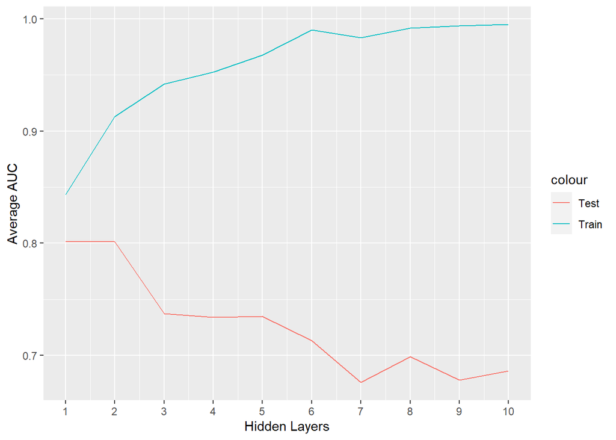

```r
ggplot(data = NULL,aes(x = 1:10,y = avgTrainROC,col='Train'))+geom_line()+
  geom_line(aes(y=avgTestROC,col='Test'))+labs(x="Hidden Layers",y='Average AUC')+
  scale_x_continuous(limits = c(1,10),breaks =seq(1,10,1) )
```

```r
nnet.model<-nnet(data=train.std,Fallimento~.,size=2,decay=0,lineout=F,maxit=10000)
nnet.prediction<-predict(nnet.model)
nnet.prediction <- predict(nnet.model, newdata=test.std)
nnet.prediction <- as.data.frame(nnet.prediction)

nnet.prediction$Output[nnet.prediction$V1 < 0.5] <- 0
nnet.prediction$Output[nnet.prediction$V1 >= 0.5] <- 1
nnet.prediction$Output <- as.factor(nnet.prediction$Output )
nnet.prediction <- as.data.frame(nnet.prediction)
nnet.prediction$Output
```

```
##  [1] 0 1 1 0 0 0 0 0 0 0 0 0 0 1 0 1 1 1 1 1 1 0 1 1 1 1 1 0 1 1 1 0 1 1 1
## [36] 1 1 1 1 0
## Levels: 0 1
```

```r
test.std$FlagFallimento
```

Confusion Matrix e Metriche

```r
confusionMatrix(nnet.prediction$Output, test.std$Fallimento)
```

```
## Confusion Matrix and Statistics
##
##           Reference
## Prediction  0  1
##          0 12  4
##          1  3 21
##
##                Accuracy : 0.825
##                  95% CI : (0.6722, 0.9266)
##     No Information Rate : 0.625
##     P-Value [Acc > NIR] : 0.005244
##
##                   Kappa : 0.6316
##
##  Mcnemar's Test P-Value : 1.000000
##
##             Sensitivity : 0.800
##             Specificity : 0.840
##          Pos Pred Value : 0.750
##          Neg Pred Value : 0.875
##              Prevalence : 0.375
##          Detection Rate : 0.300
##    Detection Prevalence : 0.400
##       Balanced Accuracy : 0.820
##
##        'Positive' Class : 0
##
```

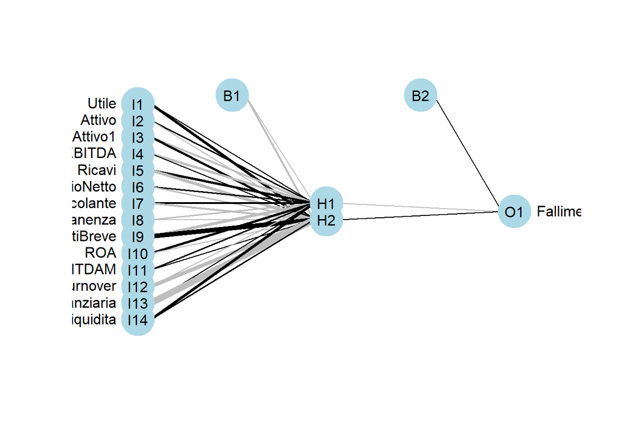

```r
plotnet(nnet.model)
```

```r
auc(roc(nnet.train$Fallimento,as.numeric(train.pred)))[1]
```

```
## [1] 0.9894444
```